# FinalProject_MiaNdousseFetter

## *TRIGGER WARNING*: Mental Health and Suicide

### The following project discusses the effects of mental health and suicide which some may find distrubing. If you struggle with suicidal thoughts/ideation, please call the Suicide and Crisis Lifeline at 988.

## Analysis of How Gender and Race are Related to Deaths Caused by Suicide

#### By: Mia Ndousse-Fetter

### Introduction:

Mental health has been a popular topic of conversation in recent years. Many beleive America specifically is facing a mental health crisis. This is affecting people in all ages and demographics but especially young people. According to the CDC, almost 1 in every 3 teenagers reported that they would describe their mental health as poor[1]. Additionally, the National Alliance on Mental Illness reports that suicide is the second leading cause of death for teenagers and young adults ages 15-24[1].

There are many reasons why someone may feel like they need to take their own life. Common risk factors include attachment to issues that occured in childhood, childhood trauma, developmental delays and mental health issues. Young people are said to become even more vulnerable as they are exposed to cultural messages, social media and drugs/alcohol [2]. Especially with recent events going on in this country and around the world including the recent Covid-19 pandemic, effects of global warming, increases political polarization, the wealth gap, racism, etc. makes it harder for younger people to have a positive outlook on life

### Motivation and Purpose:

I decided to focus on the 15-24 years old age group for this project becuase I was interested in how people my age are affected by this issue. I think it's important to bring more awareness and to discuss about mental health and suicide so people feel more comfortable to reach out and find help for themselves or a loved one. Some preventable actions that can be taken are: creating a more stable home environment, reducing substance use through community based policy and practices, and engage community members in shared activites[3].

As Suicide affects people from all walks of life, I wanted to explore if one's background (race or gender) could be related to the number of suicide deaths. If we can understand the common factors of people who are affected, then more effective efforts can be done to help decrease suicidal deaths. *In this project, I will examine if there's a statistically siginificant relationship between a race/gender and suicide rate. Null Hypothesis: There is no relationship between demogrpahic (race and gender) and suicide rate.

### Dataset/Data collection:

The data for this porject is from the U.S. Department of Health and Human Services titled Death rates for Suicide, by sex, race, hispanic origin and age: United States(https://catalog.data.gov/dataset/death-rates-for-suicide-by-sex-race-hispanic-origin-and-age-united-states-020c1). Since I'm only focusing on the 15-24 age group, I only extract rows that include that age group. I start with tidying the dataset below *Note: in the dataset the number of deaths per 100,000 people is reported in the 'ESTIMATE' column. I just refer to this number as the 'rate' for the rest of this project.

```python
#Importing relevant libraries for data collection and analysis
import pandas as pd
import seaborn as sns
import matplotlib.pyplot as plt
import numpy as np
```

```python
# reading the csv file
df = pd.read_csv(r"C:\Users\Mia\Downloads\Death_rates_for_suicide__by_sex__race__Hispanic_origin__and_age__United_States.csv")
```

### Tidying the data

```python
#Dropping columns from original dataset that are not needed.
#The columns that are left are STUB_LABEL which includes the race and gender of the observation, year, age and estimate (rate of suicide)
df.drop(['INDICATOR','UNIT', 'UNIT_NUM', 'STUB_NAME', 'STUB_NAME_NUM', 'STUB_LABEL_NUM', 'YEAR_NUM', 'AGE_NUM', 'FLAG' ], axis=1, inplace = True)
```

```python
df.head()
```

|  | STUB_LABEL | YEAR | AGE | ESTIMATE |
| --- | --- | --- | --- | --- |
| 0 | All persons | 1950 | All ages | 13.2 |
| 1 | All persons | 1960 | All ages | 12.5 |
| 2 | All persons | 1970 | All ages | 13.1 |
| 3 | All persons | 1980 | All ages | 12.2 |
| 4 | All persons | 1981 | All ages | 12.3 |

```python
#Making dataframes for each group to analyzed. This one is for all genders and all races for 15-24 years old
grouped = df.groupby(df.STUB_LABEL)
df1 = grouped.get_group("15-24 years")
```

```python
df1.head()
```

|  | STUB_LABEL | YEAR | AGE | ESTIMATE |
| --- | --- | --- | --- | --- |
| 896 | 15-24 years | 1950 | 15-24 years | 4.5 |
| 897 | 15-24 years | 1960 | 15-24 years | 5.2 |
| 898 | 15-24 years | 1970 | 15-24 years | 8.8 |
| 899 | 15-24 years | 1980 | 15-24 years | 12.3 |
| 900 | 15-24 years | 1981 | 15-24 years | 12.2 |

The STUB_LABEL column includes a description of both the race and gender of an observation. Eventually this will be split into two columns, Race and Gender, to have a better data analysis and to make the data table tidy

```python
#changing the STUB_LABEL column to have a more clear status of the gender and race.
#This will make splitting it into two seperate gender and race columns easier as well after concatenation
df1['STUB_LABEL']='All Genders: All Races: 15-24 years'
df1.head()
```

|  | STUB_LABEL | YEAR | AGE | ESTIMATE |
| --- | --- | --- | --- | --- |
| 896 | All Genders: All Races: 15-24 years | 1950 | 15-24 years | 4.5 |
| 897 | All Genders: All Races: 15-24 years | 1960 | 15-24 years | 5.2 |
| 898 | All Genders: All Races: 15-24 years | 1970 | 15-24 years | 8.8 |
| 899 | All Genders: All Races: 15-24 years | 1980 | 15-24 years | 12.3 |
| 900 | All Genders: All Races: 15-24 years | 1981 | 15-24 years | 12.2 |

```python
#Now getting the Female:15-24 years all races group
grouped = df.groupby(df.STUB_LABEL)
df2 = grouped.get_group("Female: 15-24 years")
df2.head()
```

|  | STUB_LABEL | YEAR | AGE | ESTIMATE |
| --- | --- | --- | --- | --- |
| 2156 | Female: 15-24 years | 1950 | 15-24 years | 2.6 |
| 2157 | Female: 15-24 years | 1960 | 15-24 years | 2.2 |
| 2158 | Female: 15-24 years | 1970 | 15-24 years | 4.2 |
| 2159 | Female: 15-24 years | 1980 | 15-24 years | 4.3 |
| 2160 | Female: 15-24 years | 1981 | 15-24 years | 4.6 |

```python
#modifying the dataframe like df11 so splitting the columns will be easier later
df22=df2.replace('Female: 15-24 years','Female: All Races: 15-24 years')
df22.head()
```

|  | STUB_LABEL | YEAR | AGE | ESTIMATE |
| --- | --- | --- | --- | --- |
| 2156 | Female: All Races: 15-24 years | 1950 | 15-24 years | 2.6 |
| 2157 | Female: All Races: 15-24 years | 1960 | 15-24 years | 2.2 |
| 2158 | Female: All Races: 15-24 years | 1970 | 15-24 years | 4.2 |
| 2159 | Female: All Races: 15-24 years | 1980 | 15-24 years | 4.3 |
| 2160 | Female: All Races: 15-24 years | 1981 | 15-24 years | 4.6 |

```python
#getting the Male: 15-24 years all races group
grouped = df.groupby(df.STUB_LABEL)
df3 = grouped.get_group("Male: 15-24 years")
df3.head()
```

|  | STUB_LABEL | YEAR | AGE | ESTIMATE |
| --- | --- | --- | --- | --- |
| 1568 | Male: 15-24 years | 1950 | 15-24 years | 6.5 |
| 1569 | Male: 15-24 years | 1960 | 15-24 years | 8.2 |
| 1570 | Male: 15-24 years | 1970 | 15-24 years | 13.5 |
| 1571 | Male: 15-24 years | 1980 | 15-24 years | 20.2 |
| 1572 | Male: 15-24 years | 1981 | 15-24 years | 19.7 |

```python
#modifying like df22 and df11 so splitting STUB_LABEL later will be easier
df33=df3.replace('Male: 15-24 years','Male: All Races: 15-24 years')
df33.head()
```

|  | STUB_LABEL | YEAR | AGE | ESTIMATE |
| --- | --- | --- | --- | --- |
| 1568 | Male: All Races: 15-24 years | 1950 | 15-24 years | 6.5 |
| 1569 | Male: All Races: 15-24 years | 1960 | 15-24 years | 8.2 |
| 1570 | Male: All Races: 15-24 years | 1970 | 15-24 years | 13.5 |
| 1571 | Male: All Races: 15-24 years | 1980 | 15-24 years | 20.2 |
| 1572 | Male: All Races: 15-24 years | 1981 | 15-24 years | 19.7 |

The next dataframes created will just be for the female 15-24 yrs old racial groups: American Indian or Alaskan Native, Asian or Pacific Islander, Black or African American, Hispanic or latino, and white.

```python
#df4 has the Female 15-24 yrs American Indian or Alaskan Native group
grouped = df.groupby(df.STUB_LABEL)
df4 = grouped.get_group('Female: American Indian or Alaska Native: 15-24 years')
df4.head()
```

|  | STUB_LABEL | YEAR | AGE | ESTIMATE |
| --- | --- | --- | --- | --- |
| 4300 | Female: American Indian or Alaska Native: 15-2... | 1950 | 15-24 years | NaN |
| 4301 | Female: American Indian or Alaska Native: 15-2... | 1960 | 15-24 years | NaN |
| 4302 | Female: American Indian or Alaska Native: 15-2... | 1970 | 15-24 years | NaN |
| 4303 | Female: American Indian or Alaska Native: 15-2... | 1980 | 15-24 years | NaN |
| 4304 | Female: American Indian or Alaska Native: 15-2... | 1981 | 15-24 years | NaN |

```python
#df5 has the Female 15-24 yrs Asian or Pacific Islander group
grouped = df.groupby(df.STUB_LABEL)
df5 = grouped.get_group( 'Female: Asian or Pacific Islander: 15-24 years')
df5.head()
```

|  | STUB_LABEL | YEAR | AGE | ESTIMATE |
| --- | --- | --- | --- | --- |
| 4466 | Female: Asian or Pacific Islander: 15-24 years | 1950 | 15-24 years | NaN |
| 4467 | Female: Asian or Pacific Islander: 15-24 years | 1960 | 15-24 years | NaN |
| 4468 | Female: Asian or Pacific Islander: 15-24 years | 1970 | 15-24 years | NaN |
| 4469 | Female: Asian or Pacific Islander: 15-24 years | 1980 | 15-24 years | NaN |
| 4470 | Female: Asian or Pacific Islander: 15-24 years | 1981 | 15-24 years | NaN |

```python
#df6 has the Female 15-24 yrs Black or African American group
grouped = df.groupby(df.STUB_LABEL)
df6 = grouped.get_group('Female: Black or African American: 15-24 years')
df6.head()
```

|  | STUB_LABEL | YEAR | AGE | ESTIMATE |
| --- | --- | --- | --- | --- |
| 4130 | Female: Black or African American: 15-24 years | 1950 | 15-24 years | 1.8 |
| 4131 | Female: Black or African American: 15-24 years | 1960 | 15-24 years | NaN |
| 4132 | Female: Black or African American: 15-24 years | 1970 | 15-24 years | 3.8 |
| 4133 | Female: Black or African American: 15-24 years | 1980 | 15-24 years | 2.3 |
| 4134 | Female: Black or African American: 15-24 years | 1981 | 15-24 years | 2.4 |

```python
#df7 has the Female 15-24 yrs Hispanic or Latino group
grouped = df.groupby(df.STUB_LABEL)
df7 = grouped.get_group('Female: Hispanic or Latino: All races: 15-24 years')
df7.head()
```

|  | STUB_LABEL | YEAR | AGE | ESTIMATE |
| --- | --- | --- | --- | --- |
| 6126 | Female: Hispanic or Latino: All races: 15-24 y... | 1950 | 15-24 years | NaN |
| 6127 | Female: Hispanic or Latino: All races: 15-24 y... | 1960 | 15-24 years | NaN |
| 6128 | Female: Hispanic or Latino: All races: 15-24 y... | 1970 | 15-24 years | NaN |
| 6129 | Female: Hispanic or Latino: All races: 15-24 y... | 1980 | 15-24 years | NaN |
| 6130 | Female: Hispanic or Latino: All races: 15-24 y... | 1981 | 15-24 years | NaN |

```python
#df8 has the Female 15-24 yrs White group
grouped = df.groupby(df.STUB_LABEL)
df8 = grouped.get_group('Female: White: 15-24 years')
df8.head()
```

|  | STUB_LABEL | YEAR | AGE | ESTIMATE |
| --- | --- | --- | --- | --- |
| 3962 | Female: White: 15-24 years | 1950 | 15-24 years | 2.7 |
| 3963 | Female: White: 15-24 years | 1960 | 15-24 years | 2.3 |
| 3964 | Female: White: 15-24 years | 1970 | 15-24 years | 4.2 |
| 3965 | Female: White: 15-24 years | 1980 | 15-24 years | 4.6 |
| 3966 | Female: White: 15-24 years | 1981 | 15-24 years | 4.9 |

Now doing all the Male demogrpahic groups

```python
#I will now do racial groups for men, but I will not print output for the sake of redundancy
grouped = df.groupby(df.STUB_LABEL)
df9 = grouped.get_group('Male: American Indian or Alaska Native: 15-24 years')
df10 = grouped.get_group('Male: Asian or Pacific Islander: 15-24 years')
df11 = grouped.get_group('Male: Black or African American: 15-24 years')
df12 =  grouped.get_group('Male: Hispanic or Latino: All races: 15-24 years')
df13 = grouped.get_group('Male: White: 15-24 years')
```

```python
#checking to see if it was made correctly
df13.head()
```

|  | STUB_LABEL | YEAR | AGE | ESTIMATE |
| --- | --- | --- | --- | --- |
| 3038 | Male: White: 15-24 years | 1950 | 15-24 years | 6.6 |
| 3039 | Male: White: 15-24 years | 1960 | 15-24 years | 8.6 |
| 3040 | Male: White: 15-24 years | 1970 | 15-24 years | 13.9 |
| 3041 | Male: White: 15-24 years | 1980 | 15-24 years | 21.4 |
| 3042 | Male: White: 15-24 years | 1981 | 15-24 years | 21.1 |

Concatenation:using pd.concat() to add all frames together vertically

```python
#now combining all the dataframes created
frames = [df1, df22, df33, df4, df5, df6, df7, df8, df9, df10, df11, df12, df13]
#storing new dataframe in result
result = pd.concat(frames)
```

```python
result
```

|  | STUB_LABEL | YEAR | AGE | ESTIMATE |
| --- | --- | --- | --- | --- |
| 896 | All Genders: All Races: 15-24 years | 1950 | 15-24 years | 4.5 |
| 897 | All Genders: All Races: 15-24 years | 1960 | 15-24 years | 5.2 |
| 898 | All Genders: All Races: 15-24 years | 1970 | 15-24 years | 8.8 |
| 899 | All Genders: All Races: 15-24 years | 1980 | 15-24 years | 12.3 |
| 900 | All Genders: All Races: 15-24 years | 1981 | 15-24 years | 12.2 |
| ... | ... | ... | ... | ... |
| 3076 | Male: White: 15-24 years | 2015 | 15-24 years | 20.9 |
| 3077 | Male: White: 15-24 years | 2016 | 15-24 years | 21.9 |
| 3078 | Male: White: 15-24 years | 2017 | 15-24 years | 24.4 |
| 3079 | Male: White: 15-24 years | 2018 | 15-24 years | 24.4 |
| 6300 | Male: White: 15-24 years | 2018 | 15-24 years | 24.6 |

554 rows × 4 columns

```python
#reseting index so it can start at 0
result = result.reset_index(drop=True)
```

```python
#I'm splitting the old STUB_LABEL into 3 new colums: Race, Gender, and Age. The Hispanic and Latino have 4 different ':'
#delimeters which will mess up splitting the string. Below, they are being modified into three descriptors to make the
#process easier
#first one for Male demographic
result2 = result.replace('Male: Hispanic or Latino: All races: 15-24 years','Male: Hispanic or Latino: 15-24 years')
#second one for female demographic
result3 = result2.replace('Female: Hispanic or Latino: All races: 15-24 years','Female: Hispanic or Latino: 15-24 years')
```

```python
result3
```

|  | STUB_LABEL | YEAR | AGE | ESTIMATE |
| --- | --- | --- | --- | --- |
| 0 | All Genders: All Races: 15-24 years | 1950 | 15-24 years | 4.5 |
| 1 | All Genders: All Races: 15-24 years | 1960 | 15-24 years | 5.2 |
| 2 | All Genders: All Races: 15-24 years | 1970 | 15-24 years | 8.8 |
| 3 | All Genders: All Races: 15-24 years | 1980 | 15-24 years | 12.3 |
| 4 | All Genders: All Races: 15-24 years | 1981 | 15-24 years | 12.2 |
| ... | ... | ... | ... | ... |
| 549 | Male: White: 15-24 years | 2015 | 15-24 years | 20.9 |
| 550 | Male: White: 15-24 years | 2016 | 15-24 years | 21.9 |
| 551 | Male: White: 15-24 years | 2017 | 15-24 years | 24.4 |
| 552 | Male: White: 15-24 years | 2018 | 15-24 years | 24.4 |
| 553 | Male: White: 15-24 years | 2018 | 15-24 years | 24.6 |

554 rows × 4 columns

```python
#the stub label column is pretty messy. I want to seperate it to create three seperate columns mentioned previously
result3[['Gender', 'Race','Age']] = result3['STUB_LABEL'].apply(lambda x: pd.Series(str(x).split(":")))
```

```python
result3
```

|  | STUB_LABEL | YEAR | AGE | ESTIMATE | Gender | Race | Age |
| --- | --- | --- | --- | --- | --- | --- | --- |
| 0 | All Genders: All Races: 15-24 years | 1950 | 15-24 years | 4.5 | All Genders | All Races | 15-24 years |
| 1 | All Genders: All Races: 15-24 years | 1960 | 15-24 years | 5.2 | All Genders | All Races | 15-24 years |
| 2 | All Genders: All Races: 15-24 years | 1970 | 15-24 years | 8.8 | All Genders | All Races | 15-24 years |
| 3 | All Genders: All Races: 15-24 years | 1980 | 15-24 years | 12.3 | All Genders | All Races | 15-24 years |
| 4 | All Genders: All Races: 15-24 years | 1981 | 15-24 years | 12.2 | All Genders | All Races | 15-24 years |
| ... | ... | ... | ... | ... | ... | ... | ... |
| 549 | Male: White: 15-24 years | 2015 | 15-24 years | 20.9 | Male | White | 15-24 years |
| 550 | Male: White: 15-24 years | 2016 | 15-24 years | 21.9 | Male | White | 15-24 years |
| 551 | Male: White: 15-24 years | 2017 | 15-24 years | 24.4 | Male | White | 15-24 years |
| 552 | Male: White: 15-24 years | 2018 | 15-24 years | 24.4 | Male | White | 15-24 years |
| 553 | Male: White: 15-24 years | 2018 | 15-24 years | 24.6 | Male | White | 15-24 years |

554 rows × 7 columns

```python
#dropping the old 'STUB_LABEL' column and duplicate age column
result3.drop(['STUB_LABEL','AGE' ], axis=1, inplace = True)
```

```python
result3.head()
```

|  | YEAR | ESTIMATE | Gender | Race | Age |
| --- | --- | --- | --- | --- | --- |
| 0 | 1950 | 4.5 | All Genders | All Races | 15-24 years |
| 1 | 1960 | 5.2 | All Genders | All Races | 15-24 years |
| 2 | 1970 | 8.8 | All Genders | All Races | 15-24 years |
| 3 | 1980 | 12.3 | All Genders | All Races | 15-24 years |
| 4 | 1981 | 12.2 | All Genders | All Races | 15-24 years |

```python
#renaming columns to be more descriptive
result3.rename(columns = {'YEAR':'Year', 'ESTIMATE':'Rate'}, inplace = True)
```

```python
result3.head()
```

|  | Year | Rate | Gender | Race | Age |
| --- | --- | --- | --- | --- | --- |
| 0 | 1950 | 4.5 | All Genders | All Races | 15-24 years |
| 1 | 1960 | 5.2 | All Genders | All Races | 15-24 years |
| 2 | 1970 | 8.8 | All Genders | All Races | 15-24 years |
| 3 | 1980 | 12.3 | All Genders | All Races | 15-24 years |
| 4 | 1981 | 12.2 | All Genders | All Races | 15-24 years |

```python
#Now must deal with NaN values
result4 = result3.dropna()
```

```python
#renaming columns to names that are more descriptive
result4.rename(columns = {'YEAR':'Year', 'ESTIMATE':'Rate'}, inplace = True)
```

```python
#Peak at what final tidy dataset looks like
result4
```

|  | Year | Rate | Gender | Race | Age |
| --- | --- | --- | --- | --- | --- |
| 0 | 1950 | 4.5 | All Genders | All Races | 15-24 years |
| 1 | 1960 | 5.2 | All Genders | All Races | 15-24 years |
| 2 | 1970 | 8.8 | All Genders | All Races | 15-24 years |
| 3 | 1980 | 12.3 | All Genders | All Races | 15-24 years |
| 4 | 1981 | 12.2 | All Genders | All Races | 15-24 years |
| ... | ... | ... | ... | ... | ... |
| 549 | 2015 | 20.9 | Male | White | 15-24 years |
| 550 | 2016 | 21.9 | Male | White | 15-24 years |
| 551 | 2017 | 24.4 | Male | White | 15-24 years |
| 552 | 2018 | 24.4 | Male | White | 15-24 years |
| 553 | 2018 | 24.6 | Male | White | 15-24 years |

483 rows × 5 columns

## Data Visualization and Machine Learning (ML) Analysis

The data visualizatoina and will be performed ML Analysis simultaneously. Graphs of different demographics are created. For the ML analysis, linear regression and polynomial regression are used to determine the statistical significance of our hypothesis. First gender will be analyzed, then race, and lastly gender and race.

### Analyzing Gender Only

First making a scatter plot of all data grouped by Gender

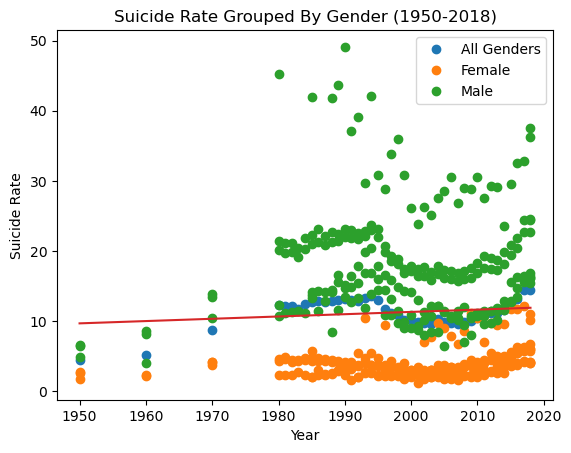

```python
#grouping dataframe by gender
Genders = result4.groupby('Gender')
fig, ax = plt.subplots()
#plotting scatter plot points by gender(group)
for group, Gender in Genders:
     ax.plot(Gender.Year, Gender.Rate, linestyle = '',marker = 'o', label = group)
#adding regression line
x = result4['Year']
y = result4['Rate']
m, b = np.polyfit(x, y, 1)
#plotting regression line
ax.plot(x, m*x+b)
#labeling graph
ax.legend()
#axis labels
plt.xlabel('Year')
plt.ylabel('Suicide Rate')
#setting title
plt.title("Suicide Rate Grouped By Gender (1950-2018)")
plt.show()
```

### Results of boxplot and scatterplot

```
[Text(0.5, 1.0, 'Rate of Suicide vs Gender')]
```

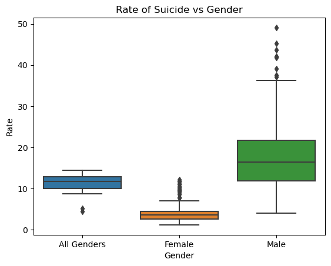

```python
#Here's a box plot to show the distribution by gender
sns.boxplot(data= result4, x = 'Gender', y = 'Rate').set(title='Rate of Suicide vs Gender')
```

Notice that the Male category has the highest rates than female and all genders. This trend will continue to be seen in the project.

Now ploting the mean suicide rate by gender over the time period of the dataset (1950-2018)

```python
result5 = result4.groupby(['Gender','Year'])['Rate'].mean()
result6 = result5.reset_index()
result6.head()
```

|  | Gender | Year | Rate |
| --- | --- | --- | --- |
| 0 | All Genders | 1950 | 4.5 |
| 1 | All Genders | 1960 | 5.2 |
| 2 | All Genders | 1970 | 8.8 |
| 3 | All Genders | 1980 | 12.3 |
| 4 | All Genders | 1981 | 12.2 |

```
[Text(0.5, 1.0, 'Mean Rate of Death By Suicide (1950-2018)')]
```

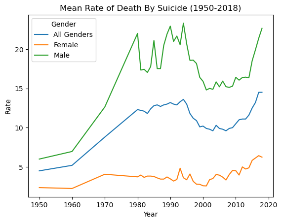

```python
import seaborn as sns
#plotting the mean rate by gender
sns.lineplot(data=result6,x='Year',y = 'Rate', hue='Gender').set(title= "Mean Rate of Death By Suicide (1950-2018)")
```

### Results of lineplot

Again, the Male group has the highest rate irrespective of race. Let's see if this relatiionship between gender and suicide rate is statistically signifcant using an Ordinary Least Squares Regression Model from the statsmodels library

```python
#now want to explore if theres a statistically significant relationship between gender and death rate using OLS regression
import statsmodels.formula.api as sm
#adding an interaction between gender
reg = sm.ols(formula="Rate ~ Year: Gender", data=result4).fit()
print(reg.summary())
```

```
                            OLS Regression Results
==============================================================================
Dep. Variable:                   Rate   R-squared:                       0.583
Model:                            OLS   Adj. R-squared:                  0.580
Method:                 Least Squares   F-statistic:                     223.1
Date:                Sun, 20 Aug 2023   Prob (F-statistic):           1.51e-90
Time:                        09:42:59   Log-Likelihood:                -1519.3
No. Observations:                 483   AIC:                             3047.
Df Residuals:                     479   BIC:                             3063.
Df Model:                           3
Covariance Type:            nonrobust
============================================================================================
                               coef    std err          t      P>|t|      [0.025      0.975]
--------------------------------------------------------------------------------------------
Intercept                  -80.6445     37.962     -2.124      0.034    -155.237      -6.052
Year:Gender[All Genders]     0.0461      0.019      2.422      0.016       0.009       0.083
Year:Gender[Female]          0.0424      0.019      2.231      0.026       0.005       0.080
Year:Gender[Male]            0.0493      0.019      2.596      0.010       0.012       0.087
==============================================================================
Omnibus:                      206.364   Durbin-Watson:                   0.196
Prob(Omnibus):                  0.000   Jarque-Bera (JB):             1127.778
Skew:                           1.801   Prob(JB):                    1.28e-245
Kurtosis:                       9.563   Cond. No.                     2.04e+05
==============================================================================

Notes:
[1] Standard Errors assume that the covariance matrix of the errors is correctly specified.
[2] The condition number is large, 2.04e+05. This might indicate that there are
strong multicollinearity or other numerical problems.
```

### Discussion on whether gender is statistically signifcant when compared to the suicide rate

In the scatterplot of all data points, boxplot and line plot of the average per year by gender, men had the highest rates. To examine the statistical siginifcance of this relationship I ran a the Ordinary Least Squares Regression alogrithm. An interaction term for Gender was added to get results from every category: all genders, female, and male. Looking at the report above, the p values are 0.016, 0.026, and 0.010 for all genders, female, and male respectively. All of these values are less than 0.05 which is the standard threshold to determine statistical significance. Thus, we can reject the null hypothesis and assume that gender does play a role in sucide rate and that men seem to be affected more than the other gender groups.

### Analyzing Race Only

I will now explore the relationship between the different racial groups and the suicide rate over time (1950-2018). These groups include American Indian or Alaskan Native, Asian or Pacific Islander, Black or African American, Hispanic or Latino, and White.

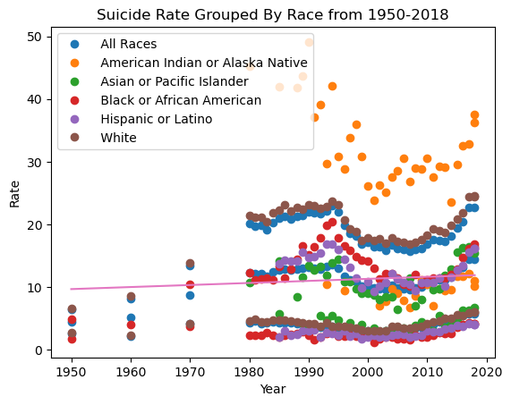

```python
#first making scatter plot with regression line grouped by race like we did with gender
#grouping dataframe by race
Races = result4.groupby('Race')
fig, ax = plt.subplots()
#plotting scatter plot points by racial group
for group, Race in Races:
     ax.plot(Race.Year, Race.Rate, linestyle = '',marker = 'o', label = group)
#adding regression line
x = result4['Year']
y = result4['Rate']
m, b = np.polyfit(x, y, 1)
#plotting regression line
ax.plot(x, m*x+b)
#labeling graph
ax.legend()
#axis labels
plt.xlabel('Year')
plt.ylabel('Rate')
#setting title
plt.title("Suicide Rate Grouped By Race from 1950-2018")
plt.show()
```

### Results of scatterplot

The output of this scatterplot is interesting because you can see for every racial group that it is divided into two areas. For example for white people, about half of the points are around a 5 rate. The rest are much higher at around a 20. I'm assuming that this means that there is a signifcant relationship between race *and* gender. That will be explored later. Below is a boxplot that will give another view of the distribution of the data by racial group.

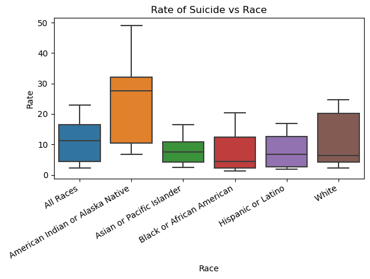

```python
#looking at distribution with box plot
plt.figure
ax = sns.boxplot(data= result4, x = 'Race', y = 'Rate')
#labeling, title, axes
ax.set(title='Rate of Suicide vs Race')
#rotating x axis labels because they were overlapping on default orientation
ax.set_xticklabels(ax.get_xticklabels(), rotation=30, ha="right")
plt.tight_layout()
plt.show()
```

### Results of boxplot

The distribution between all racial groups are similar except for the American Indian or Alaska Native group. The median for that boxplot is the highest and skewed up the highest.

```python
#grouping the data to calcuate the mean for each year by race irrespective of gender
result_race = result4.groupby(['Race','Year'])['Rate'].mean()
result_race2 = result_race.reset_index()
result_race2.head()
```

|  | Race | Year | Rate |
| --- | --- | --- | --- |
| 0 | All Races | 1950 | 4.533333 |
| 1 | All Races | 1960 | 5.200000 |
| 2 | All Races | 1970 | 8.833333 |
| 3 | All Races | 1980 | 12.266667 |
| 4 | All Races | 1981 | 12.166667 |

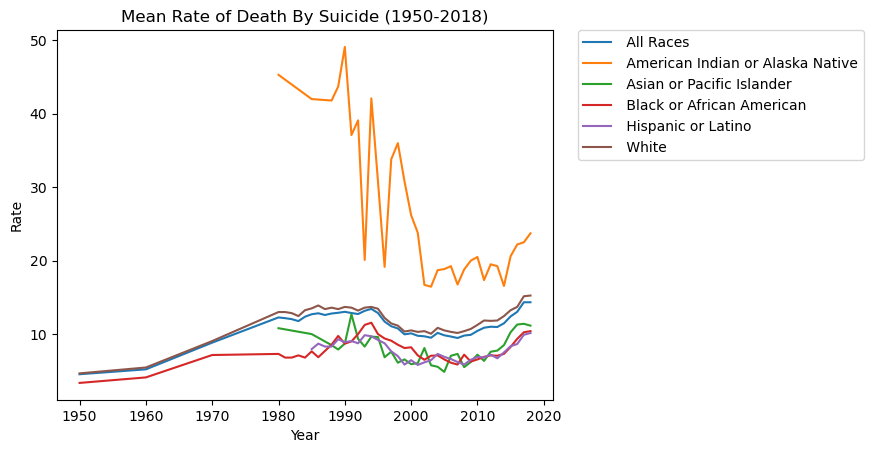

```python
#Line plot of the average rate grouped by race
sns.lineplot(data=result_race2,x='Year',y = 'Rate', hue='Race').set(title= "Mean Rate of Death By Suicide (1950-2018)")
plt.legend(bbox_to_anchor=(1.05, 1), loc='upper left', borderaxespad=0)
```

### Results of lineplot

```python
#using stats models for linear regression with an interaction for racial group
reg_race = sm.ols(formula="Rate ~ Year: Race", data=result4).fit()
print(reg_race.summary())
```

```
                            OLS Regression Results
==============================================================================
Dep. Variable:                   Rate   R-squared:                       0.312
Model:                            OLS   Adj. R-squared:                  0.303
Method:                 Least Squares   F-statistic:                     35.98
Date:                Sun, 20 Aug 2023   Prob (F-statistic):           6.23e-36
Time:                        10:20:13   Log-Likelihood:                -1640.2
No. Observations:                 483   AIC:                             3294.
Df Residuals:                     476   BIC:                             3324.
Df Model:                           6
Covariance Type:            nonrobust
================================================================================================================
                                                   coef    std err          t      P>|t|      [0.025      0.975]
----------------------------------------------------------------------------------------------------------------
Intercept                                       11.1540     50.145      0.222      0.824     -87.380     109.688
Year:Race[ All Races]                         3.695e-05      0.025      0.001      0.999      -0.049       0.049
Year:Race[ American Indian or Alaska Native]     0.0065      0.025      0.258      0.796      -0.043       0.056
Year:Race[ Asian or Pacific Islander]           -0.0016      0.025     -0.064      0.949      -0.051       0.048
Year:Race[ Black or African American]           -0.0016      0.025     -0.065      0.948      -0.051       0.048
Year:Race[ Hispanic or Latino]                  -0.0017      0.025     -0.066      0.947      -0.051       0.048
Year:Race[ White]                                0.0004      0.025      0.016      0.987      -0.049       0.050
==============================================================================
Omnibus:                        8.225   Durbin-Watson:                   0.142
Prob(Omnibus):                  0.016   Jarque-Bera (JB):                6.132
Skew:                           0.162   Prob(JB):                       0.0466
Kurtosis:                       2.554   Cond. No.                     1.54e+05
==============================================================================

Notes:
[1] Standard Errors assume that the covariance matrix of the errors is correctly specified.
[2] The condition number is large, 1.54e+05. This might indicate that there are
strong multicollinearity or other numerical problems.
```

### Discussion on whether race affects suicide rate over time

The p-values of all races (0.999), America Indian or Alaska Native (0.796), Asian or Pacific Islander (0.949), Black or African American (0.948), Hispanic or Latino (0.947), and white (0.987) are all over the alpha threshold of 0.05. The means that race is not statistically signifcant for suicide rate. These results surprised me because people of color face more systemic racism and inequality, which I thought would translate in worse mental heath and a higher suicide rate. However, this is not enough information to assert that race has absolutely no bearing on suicide rate. Other factors that are not inlcuded in this dataset like income and access to mental health should be analyzed. Since this dataset also include the gender, I will see if gender *and* race are statistically siginifcant for suicide rate in the next section.

### Analyzing Race and Gender for Suicide Rate

The significance of each gender and racial group will be examined in this next section. I will not be doing an average line plot of every race and gender combination as that plot would be really busy. Below is a scatterplot of every race and gender combination from 1950-2018. You can clearly seperate each category which shows that there may be some correlation. They seem to generally increase except for Male American Indian or Alaska Native. Some of the points also have a distinctive polynomial curve to them, which made me choose to do a polynomial regression for this gender and race analysis.

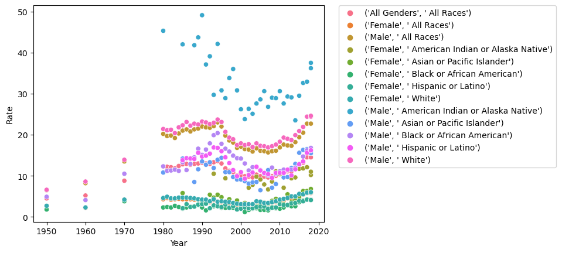

```python
sns.scatterplot(x='Year', y='Rate', data=result4,hue=result4[['Gender', 'Race']].apply(tuple, axis=1))
plt.legend(bbox_to_anchor=(1.05, 1), loc='upper left', borderaxespad=0)
```

### Polynomial regression for gender and race groups

After plotting these graphs, statsmodels regression is used for our polynomial model to give us some more statistical insights

```
('All Genders', ' All Races') r-squared=  0.9367043830374859
('Female', ' All Races') r-squared=  0.9173272509354478
('Female', ' American Indian or Alaska Native') r-squared=  0.4967916331326184
('Female', ' Asian or Pacific Islander') r-squared=  0.6587493280467036
('Female', ' Black or African American') r-squared=  0.7601999638383311
('Female', ' Hispanic or Latino') r-squared=  0.8209893551162275
('Female', ' White') r-squared=  0.9002660744880899
('Male', ' All Races') r-squared=  0.9268599368686221
('Male', ' American Indian or Alaska Native') r-squared=  0.7294978737814795
('Male', ' Asian or Pacific Islander') r-squared=  0.6711217930274314
('Male', ' Black or African American') r-squared=  0.6303684509163121
('Male', ' Hispanic or Latino') r-squared=  0.7985249180940601
('Male', ' White') r-squared=  0.9377435917822551
```

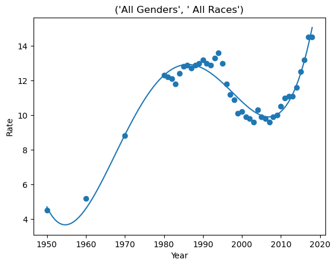

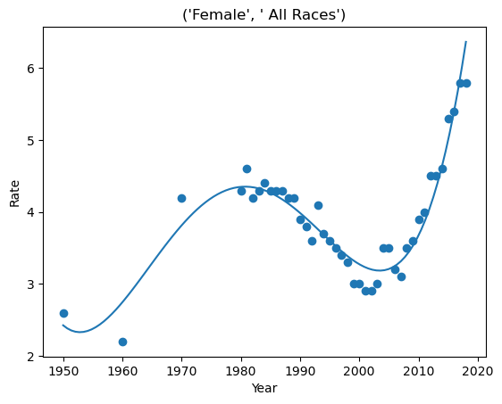

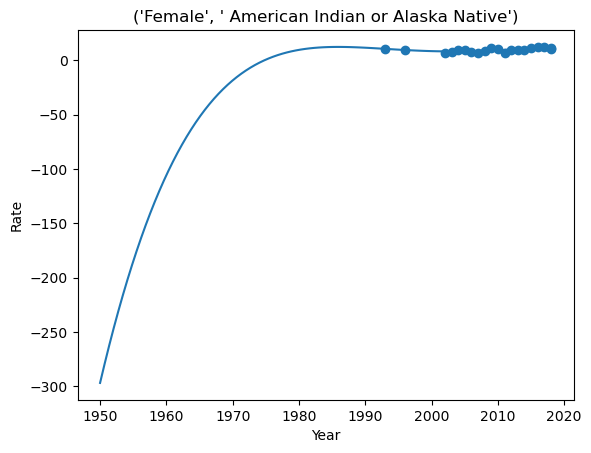

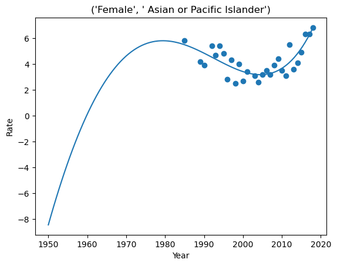

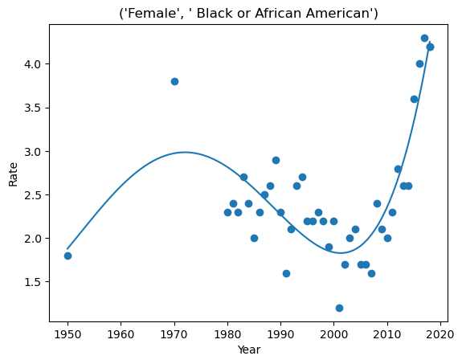

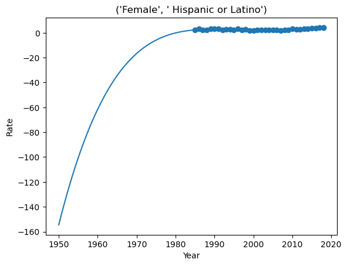

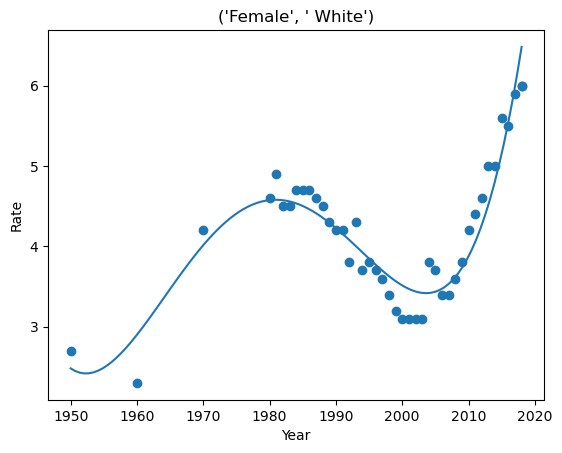

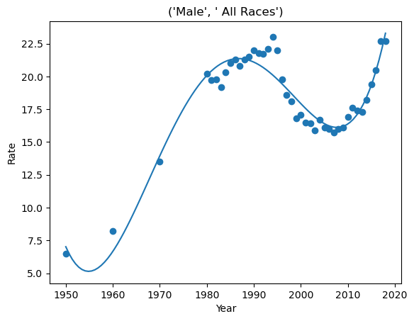

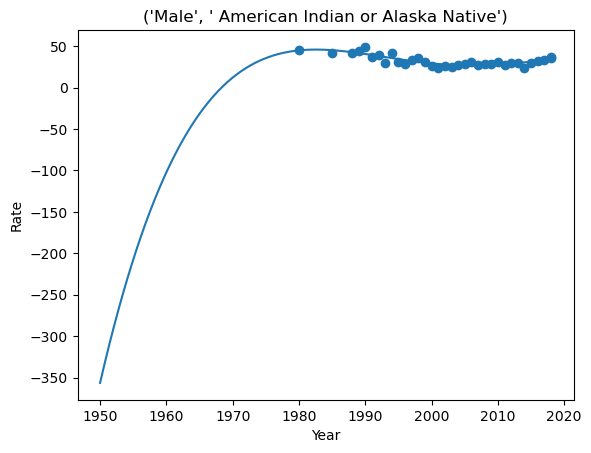

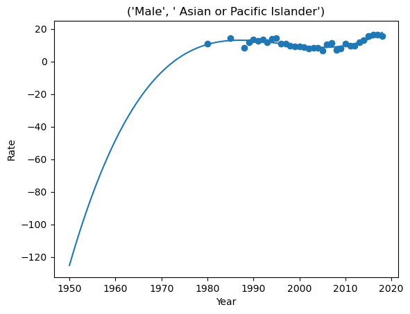

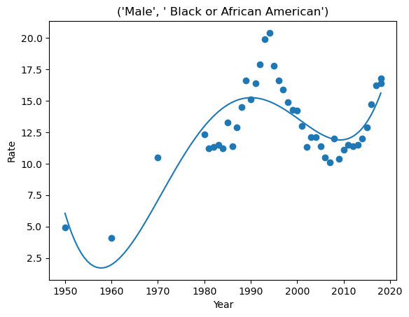

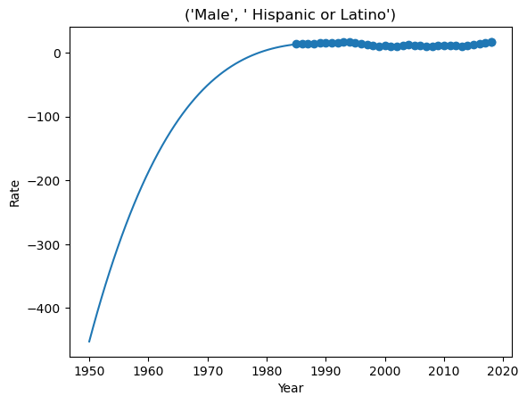

[1 more figures not shown]

```python
#scatter plot for every race and gender
from sklearn.metrics import r2_score
#grouping by gender and race
for i, group in result4.groupby(['Gender', 'Race']):
    plt.figure()
    #setting x andy variables to be used
    x=group['Year']
    y=group['Rate']
    #fitting polynomial to 4 degree
    z = np.poly1d(np.polyfit(x,y,4))
    #this sets the range of the polynomial line of best fit to be the time period of our data (1950-2018)
    line = np.linspace(1950, 2018, 100)
    #labeling title and axes
    plt.title(i)
    plt.xlabel('Year')
    plt.ylabel('Rate')
    #plotting scatter
    plt.scatter(x,y)
    #plotting line
    plt.plot(line, z(line))
    #printing r-squared values
    print(i,'r-squared= ', r2_score(y, z(x)))
```

```python
#fitting poly regression to entire dataset for race and Gender then having interaction terms
#defining our x and y dataset
x = result4['Year']
y = result4['Rate']
#fitting our model
model = np.poly1d(np.polyfit(x,y,4))
poly_reg = sm.ols(formula='y ~ model(x):Race:Gender', data=result4).fit()
#printing statistical results summary
print(poly_reg.summary())
```

```
                            OLS Regression Results
==============================================================================
Dep. Variable:                      y   R-squared:                       0.961
Model:                            OLS   Adj. R-squared:                  0.960
Method:                 Least Squares   F-statistic:                     890.5
Date:                Sun, 20 Aug 2023   Prob (F-statistic):          8.88e-321
Time:                        14:02:33   Log-Likelihood:                -946.62
No. Observations:                 483   AIC:                             1921.
Df Residuals:                     469   BIC:                             1980.
Df Model:                          13
Covariance Type:            nonrobust
========================================================================================================================================
                                                                           coef    std err          t      P>|t|      [0.025      0.975]
----------------------------------------------------------------------------------------------------------------------------------------
Intercept                                                                0.0758      0.495      0.153      0.878      -0.897       1.049
model(x):Race[ All Races]:Gender[All Genders]                            1.0069      0.049     20.523      0.000       0.910       1.103
model(x):Race[ American Indian or Alaska Native]:Gender[All Genders] -3.182e-17   1.91e-16     -0.167      0.868   -4.07e-16    3.43e-16
model(x):Race[ Asian or Pacific Islander]:Gender[All Genders]        -3.718e-16   1.87e-17    -19.924      0.000   -4.09e-16   -3.35e-16
model(x):Race[ Black or African American]:Gender[All Genders]         5.861e-16   1.44e-17     40.637      0.000    5.58e-16    6.14e-16
model(x):Race[ Hispanic or Latino]:Gender[All Genders]               -2.349e-16   1.07e-17    -21.905      0.000   -2.56e-16   -2.14e-16
model(x):Race[ White]:Gender[All Genders]                             3.249e-17   7.92e-18      4.102      0.000    1.69e-17    4.81e-17
model(x):Race[ All Races]:Gender[Female]                                 0.3407      0.049      6.945      0.000       0.244       0.437
model(x):Race[ American Indian or Alaska Native]:Gender[Female]          0.8463      0.056     15.198      0.000       0.737       0.956
model(x):Race[ Asian or Pacific Islander]:Gender[Female]                 0.3698      0.052      7.135      0.000       0.268       0.472
model(x):Race[ Black or African American]:Gender[Female]                 0.2087      0.048      4.318      0.000       0.114       0.304
model(x):Race[ Hispanic or Latino]:Gender[Female]                        0.2344      0.049      4.751      0.000       0.137       0.331
model(x):Race[ White]:Gender[Female]                                     0.3624      0.049      7.466      0.000       0.267       0.458
model(x):Race[ All Races]:Gender[Male]                                   1.6453      0.049     33.537      0.000       1.549       1.742
model(x):Race[ American Indian or Alaska Native]:Gender[Male]            2.8485      0.050     57.189      0.000       2.751       2.946
model(x):Race[ Asian or Pacific Islander]:Gender[Male]                   0.9890      0.051     19.578      0.000       0.890       1.088
model(x):Race[ Black or African American]:Gender[Male]                   1.1646      0.049     23.998      0.000       1.069       1.260
model(x):Race[ Hispanic or Latino]:Gender[Male]                          1.1142      0.049     22.584      0.000       1.017       1.211
model(x):Race[ White]:Gender[Male]                                       1.7476      0.049     36.009      0.000       1.652       1.843
==============================================================================
Omnibus:                      186.071   Durbin-Watson:                   0.934
Prob(Omnibus):                  0.000   Jarque-Bera (JB):             3184.173
Skew:                           1.201   Prob(JB):                         0.00
Kurtosis:                      15.347   Cond. No.                     4.89e+16
==============================================================================

Notes:
[1] Standard Errors assume that the covariance matrix of the errors is correctly specified.
[2] The smallest eigenvalue is 2.46e-30. This might indicate that there are
strong multicollinearity problems or that the design matrix is singular.
```

## Wrap-Up and Discussion

If were to expand this project, I think it would be interesting to introduce other age groups and see how they compare with one another. Do men have the highest rate for all gender *and* age groups? Insights from that analysis would be valuable to explore so we can exmaine the possible causes and how they may be different for different ages.

### Sources:

[1]- https://www.sanders.senate.gov/op-eds/america-is-facing-a-mental-health-crisis/#:~:text=This%20country%20faces%20a%20longstanding,especially%20devastating%20for%20young%20people.

[2]- https://www.focusonthefamily.com/parenting/why-do-teens-commit-suicide/

[3]-https://www.cdc.gov/suicide/prevention/index.html

[4]-https://www.investopedia.com/terms/r/r-squared.asp#:~:text=What%20qualifies%20as%20a%20%E2%80%9Cgood,such%20as%200.9%20or%20above.

[5]-https://www.priorygroup.com/blog/why-are-suicides-so-high-amongst-men